# W3cubDocs

/Cypress

# rightclick

Right click a DOM element.

> `.rightclick()` will not open context menus native to the browser. `.rightclick()` should be used to test your app’s handling of right click related events such as `contextmenu`.

# Syntax

```javascript
.rightclick()
.rightclick(options)
.rightclick(position)
.rightclick(position, options)
.rightclick(x, y)
.rightclick(x, y, options)
```

## Usage

**Correct Usage**

```javascript
cy.get('.menu').rightclick()       // Right click on .menu
cy.focused().rightclick()          // Right click on el with focus
cy.contains('Today').rightclick()  // Right click on first el containing 'Today'
```

**Incorrect Usage**

```javascript
cy.rightclick('button')    // Errors, cannot be chained off 'cy'
cy.window().rightclick()   // Errors, 'window' does not yield DOM element
```

## Arguments

**position** *(String)*

The position where the right click should be issued. The `center` position is the default position. Valid positions are `topLeft`, `top`, `topRight`, `left`, `center`, `right`, `bottomLeft`, `bottom`, and `bottomRight`.

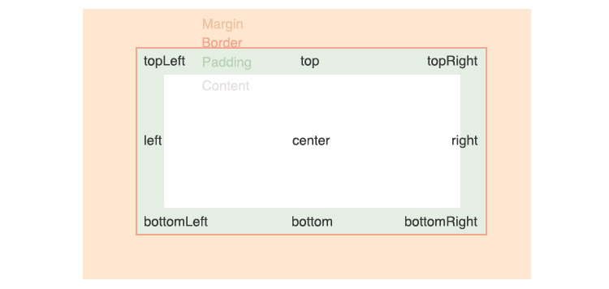

**x** *(Number)*

The distance in pixels from the element’s left to issue the right click.

**y** *(Number)*

The distance in pixels from the element’s top to issue the right click.

**options** *(Object)*

Pass in an options object to change the default behavior of `.rightclick()`.

| Option | Default | Description |
| --- | --- | --- |
| `altKey` | `false` | Activates the alt key (option key for Mac). Aliases: `optionKey`. |
| `animationDistanceThreshold` | [`animationDistanceThreshold`](https://docs.cypress.io/guides/references/configuration.html#Animations) | The distance in pixels an element must exceed over time to be [considered animating](https://docs.cypress.io/guides/core-concepts/interacting-with-elements.html#Animations). |
| `ctrlKey` | `false` | Activates the control key. Aliases: `controlKey`. |
| `force` | `false` | Forces the action, disables waiting for actionability |
| `log` | `true` | Displays the command in the [Command log](https://docs.cypress.io/guides/core-concepts/test-runner.html#Command-Log) |
| `metaKey` | `false` | Activates the meta key (Windows key or command key for Mac). Aliases: `commandKey`, `cmdKey`. |
| `multiple` | `false` | Serially click multiple elements |
| `shiftKey` | `false` | Activates the shift key. |
| `timeout` | [`defaultCommandTimeout`](https://docs.cypress.io/guides/references/configuration.html#Timeouts) | Time to wait for `.rightclick()` to resolve before timing out |
| `waitForAnimations` | [`waitForAnimations`](https://docs.cypress.io/guides/references/configuration.html#Animations) | Whether to wait for elements to [finish animating](https://docs.cypress.io/guides/core-concepts/interacting-with-elements.html#Animations) before executing the command. |

## Yields

- `.rightclick()` yields the same subject it was given from the previous command.

# Examples

## No Args

### Right click the menu

```javascript
cy.get('#open-menu').rightclick()
```

## Position

### Specify a corner of the element to right click

Right click the top right corner of the DOM element.

```javascript
cy.get('#open-menu').rightclick('topRight')
```

## Coordinates

### Specify explicit coordinates relative to the top left corner

The right click below will be issued inside of the element (15px from the left and 40px from the top).

```javascript
cy.get('#open-menu').rightclick(15, 40)
```

## Options

### Force a right click regardless of its actionable state

Forcing a right click overrides the [actionable checks](https://docs.cypress.io/guides/core-concepts/interacting-with-elements.html#Forcing) Cypress applies and will automatically fire the events.

```javascript
cy.get('#open-menu').rightclick({ force: true })
```

### Force a right click with position argument

```javascript
cy.get('#open-menu').rightclick('bottomLeft', { force: true })
```

### Force a right click with relative coordinates

```javascript
cy.get('#open-menu').rightclick(5, 60, { force: true })
```

### Right click all buttons found on the page

By default, Cypress will error if you’re trying to right click multiple elements. By passing `{ multiple: true }` Cypress will iteratively apply the right click to each element and will also log to the [Command Log](https://docs.cypress.io/guides/core-concepts/test-runner.html#Command-Log) multiple times.

```javascript
cy.get('.open-menu').rightclick({ multiple: true })
```

### Right click with key combinations

The `.rightclick()` command may also be fired with key modifiers in order to simulate holding key combinations while right clicking, such as `ALT + rightclick`.

> You can also use key combinations during `.type()`. This offers options to hold down keys across multiple commands. See Key Combinations for more information.

The following key can be combined with `.rightclick()` through the `options`..

| Option | Notes |
| --- | --- |
| `altKey` | Activates the alt key (option key for Mac). Aliases: `optionKey`. |
| `ctrlKey` | Activates the control key. Aliases: `controlKey`. |
| `metaKey` | Activates the meta key (Windows key or command key for Mac). Aliases: `commandKey`, `cmdKey`. |
| `shiftKey` | Activates the shift key. |

#### Command right click

```javascript
// execute a CMD + right click on the .menu-item
cy.get('.menu-item').rightclick({
  metaKey: true
})
```

# Notes

## Actionability

### The element must first reach actionability

`.rightclick()` is an “action command” that follows all the rules [defined here](https://docs.cypress.io/guides/core-concepts/interacting-with-elements.html).

# Rules

## Requirements

- `.rightclick()` requires being chained off a command that yields DOM element(s).

## Assertions

- `.rightclick()` will automatically wait for the element to reach an [actionable state](https://docs.cypress.io/guides/core-concepts/interacting-with-elements.html).
- `.rightclick()` will automatically wait for assertions you've chained to pass.

## Timeouts

- `.rightclick()` can time out waiting for the element to reach an [actionable state](https://docs.cypress.io/guides/core-concepts/interacting-with-elements.html).
- `.rightclick()` can time out waiting for assertions you've added to pass.

# Command Log

*Right click the DOM element*

```javascript
cy.get('.rightclick-action-div').rightclick()
```

The commands above will display in the Command Log as:

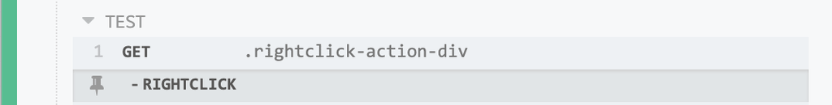

When clicking on `rightclick` within the command log, the console outputs the following:

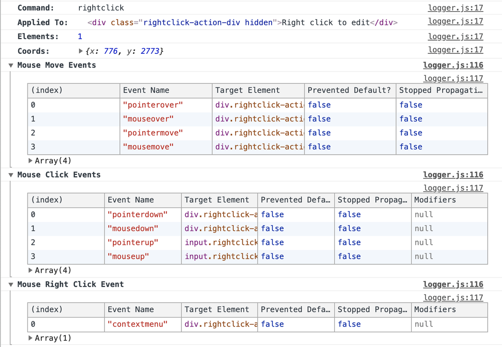

# History

| Version | Changes |
| --- | --- |
| [3.5.0](https://docs.cypress.io/guides/references/changelog.html#3-5-0) | `.rightclick()` command added |

# See also

- `.click()`
- `.dblclick()`
- `.trigger()`

© 2020 Cypress.io  
Licensed under the MIT License.  
https://docs.cypress.io/api/commands/rightclick.html